# Employee Attrition – Classification Analysis

Author

Affiliation

Yen Nguyen

Denison University

## 1. Introduction

Employee attrition refers to people leaving their jobs, either by switching roles, changing careers, or exiting an organization entirely. In this project, I focus on whether software developers are likely to consider or make a career change, using survey data from the Stack Overflow Developer Survey.

This question is especially relevant in today’s tech labor market. Since the post-COVID massive layoffs from big tech companies, the industry has been really unstable. Meanwhile, many developers continue to voluntarily switch roles due to burnout, dissatisfaction, and challenges with work–life balance. As a result, career mobility in tech is driven by both external shocks and individual preferences.

Employee turnover is also extremely costly. In 2025, replacing a technical employee can cost anywhere from 50% to over 400% of their annual salary when accounting for hiring, onboarding, and lost productivity. For companies, being able to predict which employees are more likely to leave is not just academically interesting, but financially important. Early identification of attrition risk can help organizations intervene sooner, improve retention strategies, support employee well-being, and ultimately reduce replacement costs.

Using demographic, job-related, compensation, and attitudinal factors, this project aims to identify patterns associated with developers’ likelihood of career change and explore how these characteristics relate to attrition risk.

## 2. Data & Research Design

### Data

This project uses a dataset titled the Stack Overflow 2025 Developer Survey, which includes responses from over 49,000 developers across 177 countries sharing their information and perspectives. The full survey contains 172 variables covering a wide range of topics, including demographics, education, employment status, work environment, compensation, job satisfaction, and attitudes toward emerging technologies such as artificial intelligence and large language models.

For this analysis, I focus on a subset of variables that are most relevant to individual career decision-making. Restricting the dataset in this way helps reduce noise, improves model interpretability, and allows the analysis to focus on factors that are more directly related to whether a developer considers or makes a career change.

### Research Question

Which factors predict whether a developer will consider or make a career change?

### Ethical considerations

This analysis uses publicly available, anonymized survey data. No personally identifiable information is included, and all results are reported in aggregate. The models developed in this project are intended for exploratory and educational purposes only. While the goal is to identify patterns associated with career change, the results should not be interpreted as causal or used to make decisions about specific individuals. Care was taken to avoid reinforcing stereotypes or unfair assumptions about particular demographic or professional groups.

## 3. Data Processing

### Variable Selection

To predict whether a developer is likely to consider or make a career change, I selected a set of variables that are both theoretically relevant and commonly discussed in prior research on employee mobility and attrition. Focusing on a targeted set of predictors helps to simplify the modeling process, improves interpretability, and reduces noise from overly complex or sparse features.

The selected predictors fall into the following categories:

- Demographics: Age group (`Age`), education level(`EdLevel`)
- Job-related characteristics: Employment type (`Employment`), industry (`Industry`), organization size (`OrgSize`), work arrangement (remote, hybrid, in-person) (`RemoteWork`), role type (individual contributor vs. manager) (`ICorPM`), developer type (`DevType`), and number of distinct software tools regularly used at work (`ToolCountWork`)
- Experience: Years of professional work experience (`WorkExp`)
- Compensation: Annual salary (`ConvertedCompYearly`)
- Attitudinal measures: Job satisfaction (`JobSat`) and perceived AI-related job threat (`AIThreat`)

I intentionally excluded high-dimensional or sparse multi-select variables such as country, detailed technology stacks, and programming languages. While these variables may capture important contextual differences, they often introduce strong structural effects and reduce model interpretability. Since this project focuses on individual career decision-making, the final set of variables prioritizes clarity and relevance over breadth.

```r
data <- data %>% dplyr::select("Age", "EdLevel", "WorkExp","DevType", "Employment", "OrgSize", "Industry", "ICorPM", "RemoteWork", "JobSat", "AIThreat", "ConvertedCompYearly", "ToolCountWork", "NewRole")
```

### Data Cleaning

After selecting the relevant variables, I cleaned and transformed the data to ensure consistency and suitability for modeling. Variables were converted to appropriate numeric or categorical formats, factor levels were reordered where meaningful, and long labels were shortened for readability.

Missing values were handled using median imputation for numeric variables and an “Unknown” category for categorical variables. This approach preserves observations while minimizing bias from deletion.

One notable issue involved the `ToolCountWork` variable, which was collected as a free-response numeric field. Some respondents reported extremely large values (e.g., hundreds or thousands of tools), which are not realistic. To limit the influence of these outliers, values above 50 were capped at 50.

Key transformations included:

- Age: Ordered from 18–24 through 65+
- Education level: Ordered from primary education to professional degrees
- Employment status, organization size, and remote work: Cleaned and consolidated into interpretable categories
- Target variable (`NewRole`): Recoded into a binary outcome

The binary target variable captures whether a respondent is at risk of career change:

- No_Change: Respondents who have not considered or transitioned into a new career
- Change: Respondents who have somewhat considered, strongly considered, or already transitioned into a new career (voluntary or involuntary)

```r
data <- data %>%
  filter(!is.na(NewRole)) %>%
  mutate(
    # Numeric conversions
    WorkExp = as.numeric(WorkExp),
    ConvertedCompYearly = as.numeric(ConvertedCompYearly),
    JobSat = as.numeric(JobSat),
    ToolCountWork = ifelse(ToolCountWork > 50, 50, ToolCountWork)
,
    # -----------------------------
    # Age (ordered)
    # -----------------------------
    Age = factor(case_when(
      Age == "18-24 years old" ~ "18-24",
      Age == "25-34 years old" ~ "25-34",
      Age == "35-44 years old" ~ "35-44",
      Age == "45-54 years old" ~ "45-54",
      Age == "55-64 years old" ~ "55-64",
      Age == "65 years or older" ~ "65+",
      Age == "Prefer not to say" ~ "Prefer not to say",
      TRUE ~ as.character(Age)
    ),
    levels = c("18-24","25-34","35-44","45-54","55-64","65+","Prefer not to say")
    ),

    # -----------------------------
    # Education Level (ordered)
    # -----------------------------
    EdLevel = factor(case_when(
      EdLevel == "Master’s degree (M.A., M.S., M.Eng., MBA, etc.)" ~ "Master",
      EdLevel == "Associate degree (A.A., A.S., etc.)" ~ "Associate",
      EdLevel == "Bachelor’s degree (B.A., B.S., B.Eng., etc.)" ~ "Bachelor",
      EdLevel == "Some college/university study without earning a degree" ~ "Some College",
      EdLevel == "Professional degree (JD, MD, Ph.D, Ed.D, etc.)" ~ "Professional",
      EdLevel == "Secondary school (e.g. high school)" ~ "Secondary",
      EdLevel == "Primary/elementary school" ~ "Primary",
      EdLevel == "Other (please specify):" ~ "Other",
      TRUE ~ as.character(EdLevel)
    ),
    levels = c("Primary","Secondary","Some College",
               "Associate","Bachelor","Master","Professional","Other")
    ),

    # -----------------------------
    # Employment
    # -----------------------------
    Employment = factor(case_when(
      Employment == "Employed" ~ "Employed",
      Employment == "Independent contractor, freelancer, or self-employed" ~ "Contractor/Freelancer",
      Employment == "Student" ~ "Student",
      Employment == "Retired" ~ "Retired",
      Employment == "Not employed" ~ "Not employed",
      Employment == "I prefer not to say" ~ "Prefer not to say",
      TRUE ~ as.character(Employment)
    )),

    # -----------------------------
    # OrgSize (ordered)
    # -----------------------------
    OrgSize = factor(case_when(
      OrgSize == "Less than 20 employees" ~ "<20",
      OrgSize == "20 to 99 employees" ~ "20-99",
      OrgSize == "100 to 499 employees" ~ "100-499",
      OrgSize == "500 to 999 employees" ~ "500-999",
      OrgSize == "1,000 to 4,999 employees" ~ "1k-4.9k",
      OrgSize == "5,000 to 9,999 employees" ~ "5k-9.9k",
      OrgSize == "10,000 or more employees" ~ "10k+",
      OrgSize == "Just me - I am a freelancer, sole proprietor, etc." ~ "Solo/Freelancer",
      OrgSize == "I don’t know" ~ "Unknown",
      TRUE ~ as.character(OrgSize)
    ),
    levels = c("<20","20-99","100-499","500-999","1k-4.9k","5k-9.9k","10k+","Solo/Freelancer","Unknown")
    ),

    # -----------------------------
    # Remote Work (ordered)
    # -----------------------------
    RemoteWork = factor(case_when(
      RemoteWork == "Remote" ~ "Remote",
      RemoteWork == "In-person" ~ "In-person",
      RemoteWork == "Hybrid (some in-person, leans heavy to flexibility)" ~ "Hybrid (flex remote)",
      RemoteWork == "Hybrid (some remote, leans heavy to in-person)" ~ "Hybrid (flex in-person)",
      RemoteWork == "Your choice (very flexible, you can come in when you want or just as needed)" ~ "Flexible Choice",
      TRUE ~ as.character(RemoteWork)
    ),
    levels = c("In-person","Hybrid (flex in-person)","Hybrid (flex remote)","Remote","Flexible Choice")
    ),

    # -----------------------------
    # Other categories
    # -----------------------------
    ICorPM = factor(ICorPM),
    Industry = as.factor(Industry),
    AIThreat = factor(AIThreat, levels = c("No", "Yes", "I'm not sure")),
    DevType = factor(DevType),
    # -----------------------------
    # NewRole (target variable)
    # -----------------------------
    NewRole = factor(case_when(
      NewRole == "I have neither consider or transitioned into a new career or industry" ~ "No_Change",
      TRUE ~ "Change"
      ))
    )
```

## 4. Data Exploration

### Target Variable Distribution

We first look at the target variable, NewRole, which captures whether a developer has considered or made a career change.

```r
data %>%
  count(NewRole) %>%
  ggplot(aes(x = NewRole, y = n, fill = NewRole)) +
  geom_col() +
  labs(title = "Career Change Distribution", x = "Career Change", y = "Count") +
  theme_minimal()
```

**Plot**

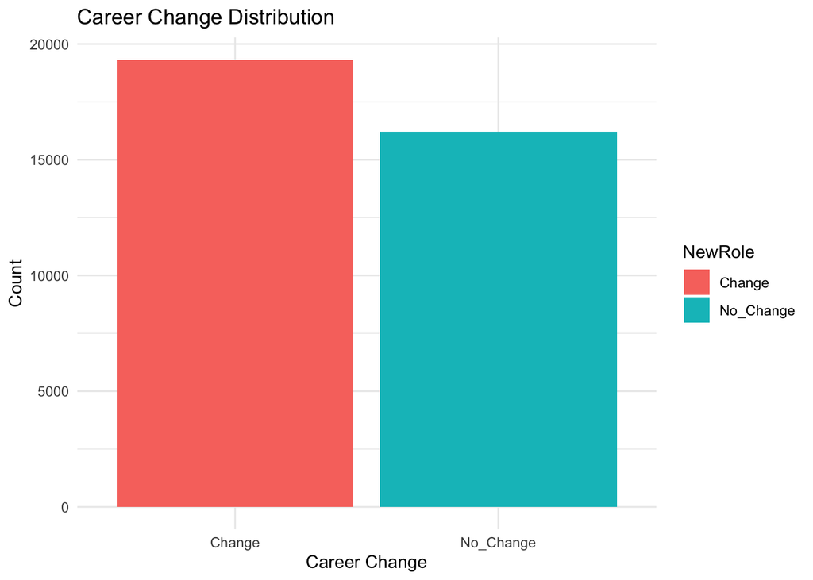

From the plot, there are:

- Change: over 19000 respondents
- No Change: over 16000 respondents

Slightly more developers are considering or making a career change than staying in their current role, but the classes are reasonably balanced, which is helpful for modeling.

### Continuous Variables

We explored numeric variables to understand patterns in experience, salary, job satisfaction, and tool usage:

- `WorkExp`: Years of professional experience
- `ConvertedCompYearly`: Annual salary
- `JobSat`: Job satisfaction (1–10 scale)
- `ToolCountWork`: Number of distinct software tools used at work

```r
continuous_vars <- c("WorkExp", "ConvertedCompYearly", "JobSat", "ToolCountWork")

data %>%
  dplyr::select(all_of(continuous_vars)) %>%
  gather(key = "variable", value = "value") %>%
  filter(!is.na(value)) %>%
  ggplot(aes(x = value)) +
  geom_histogram(bins = 30, fill = "steelblue", color = "white") +
  facet_wrap(~variable, scales = "free") +
  labs(title = "Distribution of Continuous Predictors") +
  theme_minimal()

# Log-transformed salary
data %>%
  filter(!is.na(ConvertedCompYearly) & ConvertedCompYearly > 0) %>%
  ggplot(aes(x = log(ConvertedCompYearly))) +
  geom_histogram(bins = 30, fill = "darkblue", color = "white") +
  labs(title = "Log-Transformed Salary Distribution",
       x = "log(ConvertedCompYearly)", y = "Count") +
  theme_minimal()
```

**Plot**

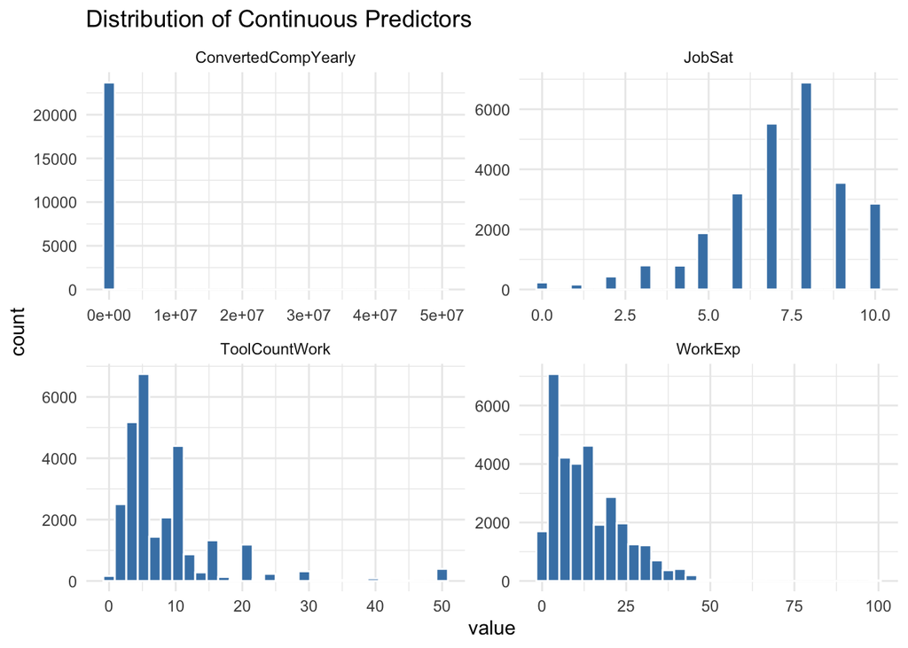

**Plot**

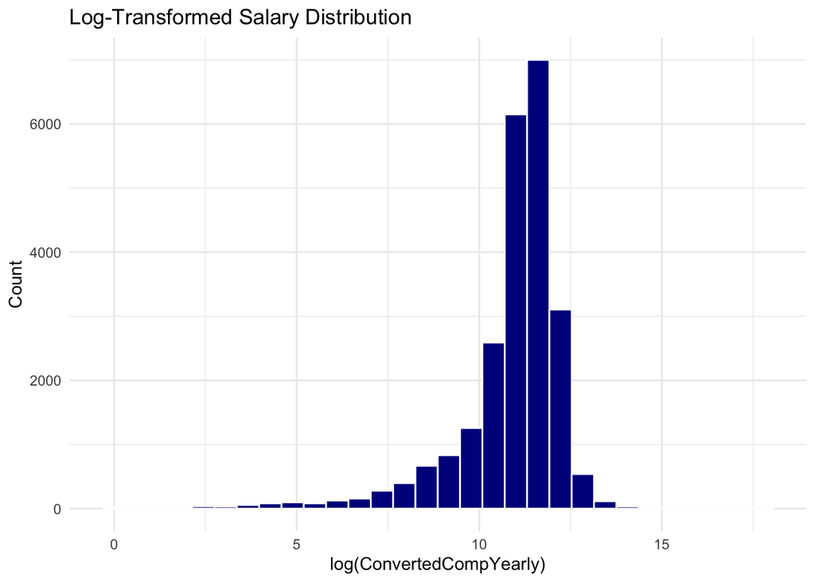

```r
# Correlation matrix
numeric_vars <- data %>%
  dplyr::select(all_of(continuous_vars)) %>%
  na.omit()

cor_matrix <- cor(numeric_vars)
print(cor_matrix)
```

**Output**

```
                       WorkExp ConvertedCompYearly       JobSat ToolCountWork
WorkExp             1.00000000          0.08400925 0.1029740771  0.1198903290
ConvertedCompYearly 0.08400925          1.00000000 0.0216326804  0.0403308107
JobSat              0.10297408          0.02163268 1.0000000000  0.0001519641
ToolCountWork       0.11989033          0.04033081 0.0001519641  1.0000000000
```

The numeric predictors show very weak correlations with each other:

- Work experience has a slight positive correlation with salary (0.08) and number of tools used (0.12).
- Job satisfaction is almost uncorrelated with salary (0.02) and tool count (~0). Overall, experience, salary, satisfaction, and tool usage are largely independent.

Relation to career change

```r
cont_vars <- c("WorkExp", "JobSat", "ConvertedCompYearly")

plot_data <- data %>%
  select(NewRole, all_of(cont_vars)) %>%
  pivot_longer(
    cols = -NewRole,
    names_to = "Variable",
    values_to = "Value"
  ) %>%
  filter(!is.na(Value)) %>%
  mutate(
    Value = ifelse(
      Variable == "ConvertedCompYearly",
      log(Value),
      Value
    ),
    Variable = recode(
      Variable,
      WorkExp = "Work Experience (Years)",
      JobSat = "Job Satisfaction",
      ConvertedCompYearly = "Log Compensation"
    )
  )

ggplot(plot_data, aes(x = NewRole, y = Value, fill = NewRole)) +
  geom_boxplot(alpha = 0.7, outlier.alpha = 0.3) +
  facet_wrap(~ Variable, scales = "free_y", ncol = 2) +
  labs(
    title = "Continuous Predictors by Career Change Status",
    x = "Career Change",
    y = NULL
  ) +
  theme_minimal() +
  theme(
    legend.position = "none",
    strip.text = element_text(face = "bold")
  )
```

**Plot**

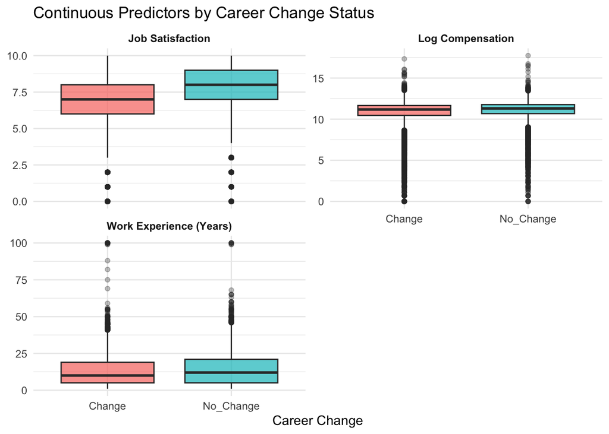

- Developers with less experience and lower job satisfaction are more likely to consider changing roles.
- There is a weak indication that developers with lower log compensation are more likely to consider changing roles.

### Categorical Variables

Categorical variables provide context about demographics, education, and workplace features:

```r
cat_groups <- list(
  Demographics = c("Age", "EdLevel"),
  Job = c("Employment", "OrgSize", "ICorPM", "RemoteWork"),
  Attitudes = c("AIThreat")
)

for (group in names(cat_groups)) {

  plot_data <- data %>%
    select(NewRole, all_of(cat_groups[[group]])) %>%
    pivot_longer(
      cols = -NewRole,
      names_to = "Variable",
      values_to = "Value"
    ) %>%
    filter(!is.na(Value))

  p <- ggplot(plot_data, aes(x = Value, fill = NewRole)) +
    geom_bar() +
    facet_wrap(~ Variable, scales = "free_x", ncol = 2) +
    labs(
      title = paste(group, "Variables by Career Change"),
      x = NULL,
      y = "Proportion"
    ) +
    theme_minimal() +
    theme(
      axis.text.x = element_text(angle = 45, hjust = 1),
      legend.position = "bottom",
      strip.text = element_text(face = "bold")
    )

  print(p)
}
```

**Plot**

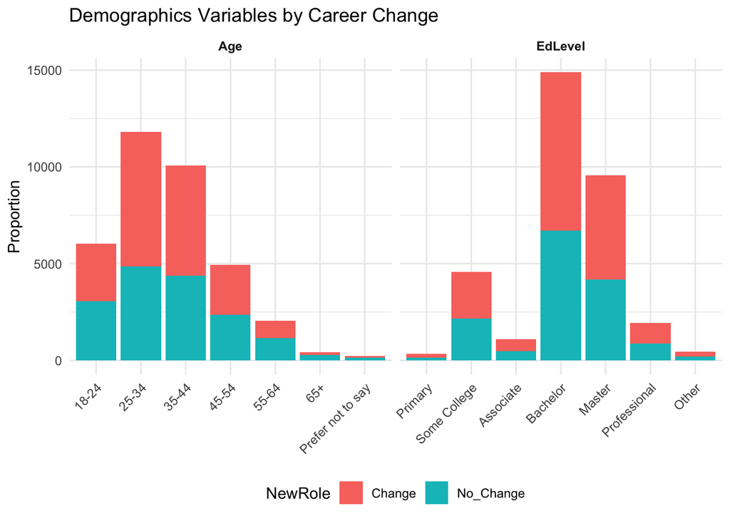

**Plot**

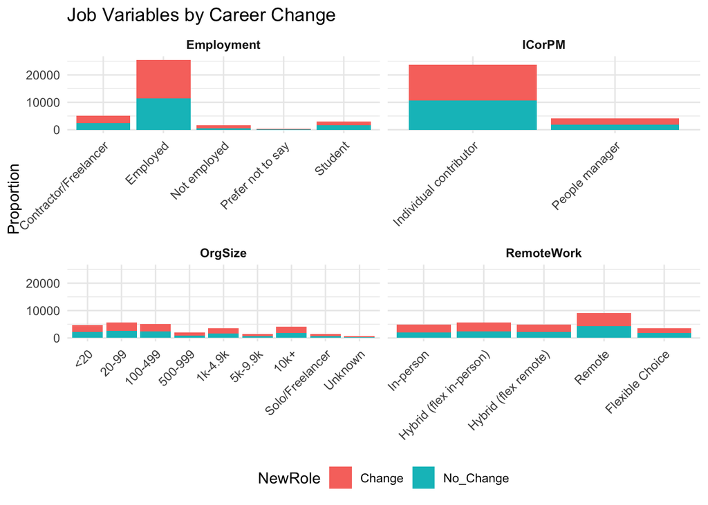

**Plot**

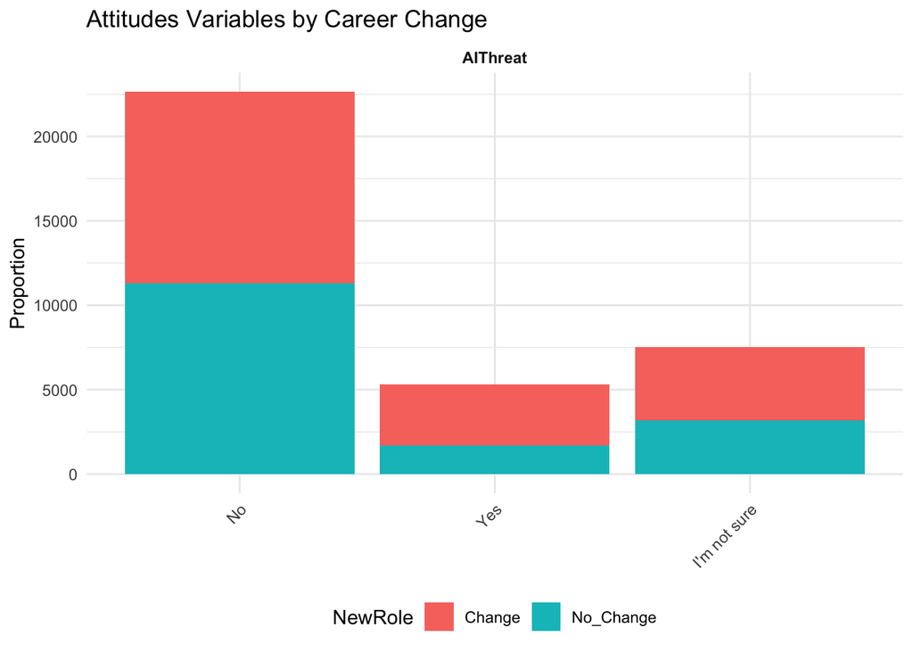

Observations:

- Age: Younger professionals (25–44) are more likely to consider career change.
- Education: Those with bachelor’s or master’s degrees are more likely to consider or have changed roles.
- Employment type, organization size & role type: No strong influence on career change.
- Remote work: Flexible or remote arrangements are associated with stability.
- AI threat perception: Those perceiving AI threat are more likely to consider change.

For variables with many categories like Industry and Developer Type, the top categories dominate:

```r
top_n <- 10
large_cats <- c("Industry", "DevType")

plots <- list()

for(var in large_cats){
  top_values <- data %>%
    filter(!is.na(.data[[var]])) %>%
    count(value = .data[[var]]) %>%
    slice_max(n, n = top_n)

  p <- ggplot(top_values, aes(x = reorder(value, n), y = n)) +
    geom_col(fill = "darkgreen") +
    coord_flip() +
    labs(title = paste("Top", top_n, "categories in", var), x = NULL, y = "Count") +
    theme_minimal(base_size = 12)

  plots[[var]] <- p
}

# Combine plots in a grid
grid.arrange(grobs = plots, ncol = 1)
```

**Plot**

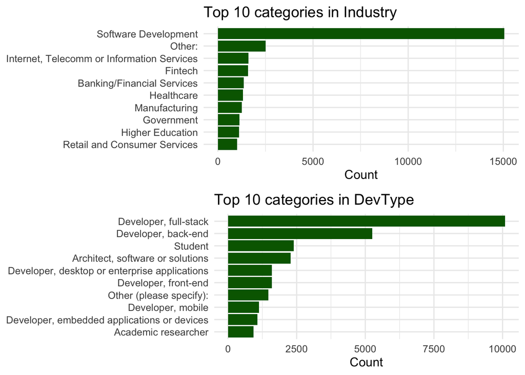

- `Industry`: Responses are dominated by Software Development, Internet/Information Services, Telecommunications, FinTech, Banking/Financial Services, and Healthcare, showing that participants are primarily employed in tech-driven and professional sectors.
- `DevType` (Developer Type): The most common roles include Full-Stack Developers, Back-End Developers, Front-End Developers, Software/Solutions Architects, and Students, reflecting a respondent pool centered around core development and engineering positions.

### Summary Insights

- About 54% of respondents are considering or have already changed careers, while 46% have stayed in their current roles. The classes are fairly balanced.
- Most respondents are new or mid-career developers who have worked for several years and generally report high job satisfaction.
- Work experience and the number of tools used at work are only weakly correlated with compensation and job satisfaction.
- Career mobility appears to be influenced more by factors like experience, satisfaction, age, and work context (e.g., remote flexibility, employment type) rather than salary.

Overall, the dataset represents a technically skilled and fairly experienced workforce, with a significant subset actively considering or undergoing career transitions.

## 5. Model Selection

Our goal is to predict whether a developer is likely to consider or make a career change (`NewRole`). Since this is a binary outcome (`Change` vs `No_Change`) and most predictors are categorical, we focused on models that handle categorical data well:

- Naive Bayes – A simple probabilistic model that’s easy to interpret and provides a quick baseline.
- Logistic Regression – Handles multiple predictors and gives interpretable coefficients in terms of odds ratios.
- Random Forests – Captures non-linear relationships, works naturally with categorical variables, and reduces variance by averaging across multiple decision trees.

We skipped distance-based models like K-Nearest Neighbors because they perform poorly with many categorical variables. These three models give a good mix of interpretability and predictive performance.

## 6. Modeling

### Data Preprocessing & Train-Test Split

Before training models, we handled missing values and prepared the dataset:

- Categorical variables: Missing values were replaced with “Unknown”.
- Numeric variables: Missing values were filled with the median, which is robust to skewed distributions.

We then split the data into training (70%) and testing (30%) sets, ensuring the target variable’s reference level is No_Change, so that we could make sure our models are predicting if a developer is likely to consider career change (positive class = Change).

Since compensation is really skewed, we’ll log-transform it for logistic regression and Naive Bayes to make the models work better, but we’ll keep the original values for Random Forest because it handles skewed data fine.

```r
# Handle missing values and drop the old NewRole col
data <- data %>%
  mutate(across(where(is.factor), ~ fct_explicit_na(., "Unknown")),
         across(where(is.numeric), ~ ifelse(is.na(.), median(., na.rm = TRUE), .)))

# Train-test split
set.seed(123)
train_idx <- createDataPartition(data$NewRole, p = 0.7, list = FALSE)
train <- data[train_idx, ]
test  <- data[-train_idx, ]

train$NewRole <- relevel(train$NewRole, ref = "No_Change")
test$NewRole  <- relevel(test$NewRole, ref = "No_Change")

train_nb_logit <- train %>%
  mutate(log_compensation = log(ConvertedCompYearly)) %>%
  select(-ConvertedCompYearly)
test_nb_logit <- test %>%
  mutate(log_compensation = log(ConvertedCompYearly)) %>%
  select(-ConvertedCompYearly)
```

### Naives Bayes

Naive Bayes serves as a simple baseline model. It assumes independence among predictors and calculates probabilities for each class.

```r
set.seed(123)

# Train Naive Bayes
ctrl <- trainControl(
  method = "repeatedcv",
  number = 5,
  repeats = 10,
  summaryFunction = twoClassSummary,
  classProbs = TRUE,
  savePredictions = "final"
)

nb_model <- train(
  NewRole ~ ., data = train_nb_logit,
  method = "naive_bayes",
  metric = "ROC",
  tuneLength = 10,
  trControl = ctrl
)

# Confusion matrix
nb_pred <- predict(nb_model, test_nb_logit)
confusionMatrix(nb_pred, test_nb_logit$NewRole, positive = "Change")

# ROC curve
nb_probs <- predict(nb_model, test_nb_logit, type = "prob")[, "Change"]

roc_obj <- pROC::roc(
  response  = test_nb_logit$NewRole,
  predictor = nb_probs,
  levels    = rev(levels(test_nb_logit$NewRole))
)

plot(roc_obj, print.auc = TRUE, main = "Naive Bayes ROC curve")
```

**Output**

```
Confusion Matrix and Statistics

           Reference
Prediction  No_Change Change
  No_Change      2572   1759
  Change         2289   4037

               Accuracy : 0.6202
                 95% CI : (0.6109, 0.6294)
    No Information Rate : 0.5439
    P-Value [Acc > NIR] : < 2.2e-16

                  Kappa : 0.2276

 Mcnemar's Test P-Value : < 2.2e-16

            Sensitivity : 0.6965
            Specificity : 0.5291
         Pos Pred Value : 0.6382
         Neg Pred Value : 0.5939
             Prevalence : 0.5439
         Detection Rate : 0.3788
   Detection Prevalence : 0.5936
      Balanced Accuracy : 0.6128

       'Positive' Class : Change
```

**Plot**

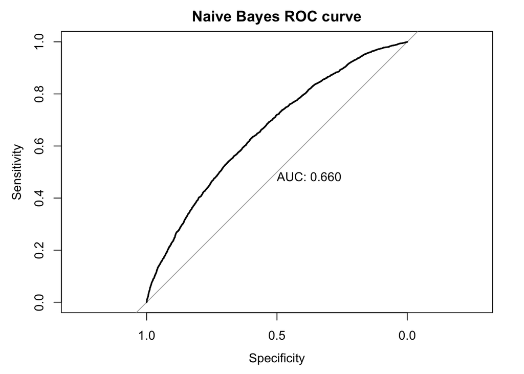

### Logistic Regression

Logistic regression estimates the probability of a career change using a linear combination of predictors. To classify developers, we select an optimal probability cutoff based on cross-validated predictions, choosing the threshold that maximizes Youden’s J, rather than using the default 0.5.

```r
set.seed(123)

# Train logistic regression
logit_model <- train(
  NewRole ~ .,
  data = train_nb_logit,
  method = "glm",
  family = binomial(),
  metric = "ROC",
  trControl = ctrl
)

cv_preds <- logit_model$pred

# ROC based on CV predictions
roc_cv <- pROC::roc(
  response  = cv_preds$obs,
  predictor = cv_preds$Change,  # predicted probability of 'Change'
  levels    = rev(levels(cv_preds$obs))
)

# Optimal threshold based on Youden's J (maximize overall accuracy)
cutoff <- coords(roc_cv, "best", ret = "threshold")$threshold

cutoff

# Visualize ROC curve with best threshold
plot(roc_cv, print.auc = TRUE, print.thres = "best",
     main = "Logistic Regression ROC (CV-based cutoff)")
```

**Output**

```
[1] 0.5239197
```

**Plot**

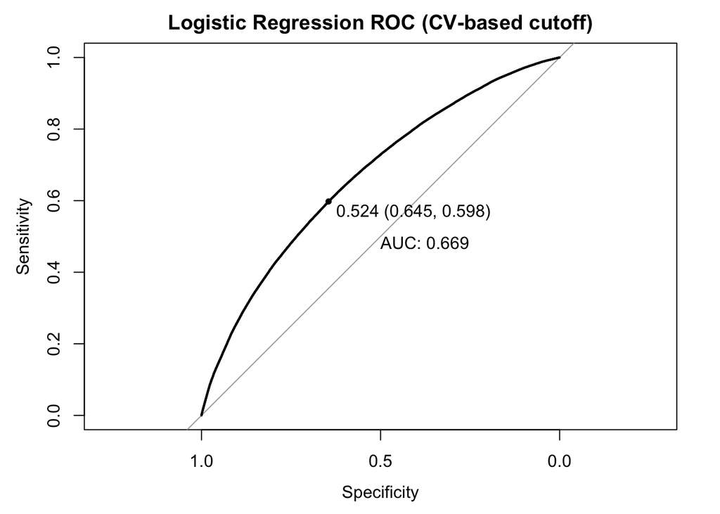

```r
# Predicted probabilities on test set
test_probs <- predict(logit_model, test_nb_logit, type = "prob")[, "Change"]

# Apply Sensitivity-optimal cutoff
pred_test <- factor(ifelse(test_probs > cutoff, "Change", "No_Change"),
                      levels = levels(test_nb_logit$NewRole))

# Confusion matrices
cm_test <- confusionMatrix(pred_test, test_nb_logit$NewRole, positive = "Change")

cm_test
```

**Output**

```
Confusion Matrix and Statistics

           Reference
Prediction  No_Change Change
  No_Change      3002   2044
  Change         1859   3752

               Accuracy : 0.6338
                 95% CI : (0.6245, 0.6429)
    No Information Rate : 0.5439
    P-Value [Acc > NIR] : < 2.2e-16

                  Kappa : 0.2641

 Mcnemar's Test P-Value : 0.003227

            Sensitivity : 0.6473
            Specificity : 0.6176
         Pos Pred Value : 0.6687
         Neg Pred Value : 0.5949
             Prevalence : 0.5439
         Detection Rate : 0.3521
   Detection Prevalence : 0.5265
      Balanced Accuracy : 0.6325

       'Positive' Class : Change
```

#### Odd-ratio Summary

```r
# Odd-ratio summary
logit_model_glm <- logit_model$finalModel
logit_summary <- tidy(logit_model_glm, exponentiate = TRUE, conf.int = TRUE)
DT::datatable(
  logit_summary,
  options = list(
    pageLength = 10,       # show 10 rows per page
    scrollX = TRUE          # horizontal scroll for wide tables
  )
)
```

|  | term | estimate | std.error | statistic | p.value | conf.low | conf.high |
| --- | --- | --- | --- | --- | --- | --- | --- |
| 1 | (Intercept) | 22.0573243096343 | 0.2374405962911704 | 13.02913134189103 | 8.355344476155036e-39 | 13.86265219257415 | 35.16720410696362 |
| 2 | `Age25-34` | 1.276570223310611 | 0.04710589771749759 | 5.183575314423595 | 2.176722705656046e-07 | 1.163968529955358 | 1.400036885604912 |
| 3 | `Age35-44` | 1.220879425887018 | 0.05499870714481251 | 3.628656932419854 | 0.00028489954302174 | 1.096105149759389 | 1.359841278950724 |
| 4 | `Age45-54` | 1.10226593042891 | 0.07228658398468658 | 1.346971905851404 | 0.1779892810496007 | 0.956619758677297 | 1.270032121825566 |
| 5 | `Age55-64` | 0.8204123006841342 | 0.09716845391143654 | -2.037165884684489 | 0.04163342131990493 | 0.6780355840384247 | 0.9924297575301948 |
| 6 | `Age65+` | 0.5508619276420449 | 0.1670386213858085 | -3.56966000632486 | 0.0003574448397524643 | 0.3958850146393819 | 0.7623116680202634 |
| 7 | `AgePrefer not to say` | 0.5612682572265556 | 0.186399754088283 | -3.098482150365907 | 0.001945146871057605 | 0.3873248062649422 | 0.8053091254337612 |
| 8 | EdLevelSecondary |  |  |  |  |  |  |
| 9 | `EdLevelSome College` | 0.9666283367046948 | 0.1443444313923703 | -0.2351403779087708 | 0.8140997800913622 | 0.7277763395057965 | 1.282234442945189 |
| 10 | EdLevelAssociate | 0.9936029413245757 | 0.1586852069557759 | -0.04044238061073463 | 0.9677404430289598 | 0.7275107749227099 | 1.355722287040351 |

[output cut: 77 more lines]

Observations:

- Demographics: Younger developers (ages 25–44) are more likely to switch jobs, while older developers (55+) are less likely. Education level doesn’t seem to have an impact, but more work experience noticeably reduces the odds of switching.
- Job factors: Job satisfaction lowers the likelihood of switching. Certain roles, such as data or business analysts, full-stack developers, desktop or enterprise application developers, and students, tend to switch less. Freelancers or solo workers are more likely to change jobs. Organization size doesn’t appear to have a significant effect, and developers in the software development industry are slightly less likely to leave, while other industries show no clear effect. Using a greater number of distinct tools at work, reflecting higher job complexity, significantly increases switching likelihood.
- Compensation: Higher log-transformed compensation is associated with a lower probability of switching.
- Attitudinal factors: Job satisfaction clearly reduces switching, whereas perceiving AI as a threat significantly increases the likelihood of leaving.

### Random Forest

We train a Random Forest to predict career change, using ROC-based cross-validation to optimize the probability threshold for detecting developers likely to change roles.

```r
set.seed(123)

# Train Random Forest
rf_ctrl <- trainControl(
  method = "cv",
  number = 3,
  classProbs = TRUE,
  summaryFunction = twoClassSummary  # Needed for ROC
)

rf_model <- train(
  NewRole ~ .,
  data = train,
  method = "ranger",
  metric = "ROC",
  tuneLength = 5,
  trControl = rf_ctrl,
  importance = "impurity",
  verbose = FALSE
)

# Predict probabilities on the test set
rf_probs <- predict(rf_model, test, type = "prob")[, "Change"]

# ROC curve and optimal threshold selection
roc_rf <- roc(response = test$NewRole,
              predictor = rf_probs,
              levels = rev(levels(test$NewRole)))

# Best cutoff using Youden's J
rf_cutoff <- coords(roc_rf, "best", ret = "threshold")$threshold
rf_cutoff

# Apply optimal cutoff
rf_pred_opt <- factor(ifelse(rf_probs > rf_cutoff, "Change", "No_Change"),
                      levels = levels(test$NewRole))

# Confusion matrix using optimized threshold
confusionMatrix(rf_pred_opt, test$NewRole, positive = "Change")

# Plot ROC with threshold
plot(roc_rf, print.auc = TRUE, print.thres = TRUE,
     main = paste("Random Forest ROC (cutoff =", round(rf_cutoff, 2), ")"))
```

**Output**

```
[1] 0.5448963
Confusion Matrix and Statistics

           Reference
Prediction  No_Change Change
  No_Change      3116   2196
  Change         1745   3600

               Accuracy : 0.6302
                 95% CI : (0.6209, 0.6394)
    No Information Rate : 0.5439
    P-Value [Acc > NIR] : < 2e-16

                  Kappa : 0.2602

 Mcnemar's Test P-Value : 7.6e-13

            Sensitivity : 0.6211
            Specificity : 0.6410
         Pos Pred Value : 0.6735
         Neg Pred Value : 0.5866
             Prevalence : 0.5439
         Detection Rate : 0.3378
   Detection Prevalence : 0.5015
      Balanced Accuracy : 0.6311

       'Positive' Class : Change
```

**Plot**

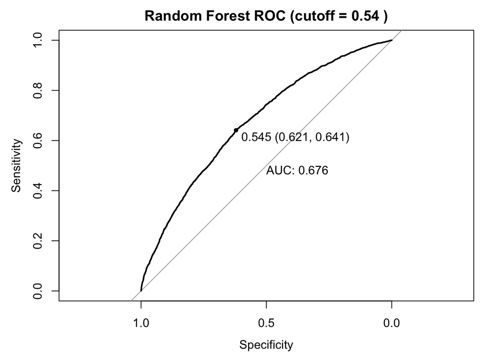

#### Feature importance

```r
# Extract variable importance from the trained Random Forest
rf_varimp <- varImp(rf_model, scale = TRUE)$importance

# Add variable names as a column
rf_varimp <- data.frame(
  Variable = rownames(rf_varimp),
  Overall  = rf_varimp$Overall,
  stringsAsFactors = FALSE
)

# Automatically map dummies back to original variables
map_to_orig <- function(var_name, predictors) {
  matches <- predictors[sapply(predictors, function(p) startsWith(as.character(var_name), as.character(p)))]
  if(length(matches) > 0) return(matches[which.max(nchar(matches))]) else return(var_name)
}

predictors <- names(train)[names(train) != "NewRole"]
rf_varimp$OrigVar <- sapply(rf_varimp$Variable, map_to_orig, predictors = predictors)

# Aggregate importance per original variable (mean across dummies)
agg_varimp <- rf_varimp %>%
  group_by(OrigVar) %>%
  summarise(Importance = mean(Overall, na.rm = TRUE)) %>%
  arrange(desc(Importance))

# Plot top 10
top_varimp <- agg_varimp[1:10, ]

ggplot(top_varimp, aes(x = reorder(OrigVar, Importance), y = Importance)) +
  geom_col(fill = "steelblue") +
  coord_flip() +
  labs(title = "Top 10 Random Forest Feature Importance (Aggregated)",
       x = "Feature",
       y = "Mean Importance") +
  theme_minimal()
```

**Plot**

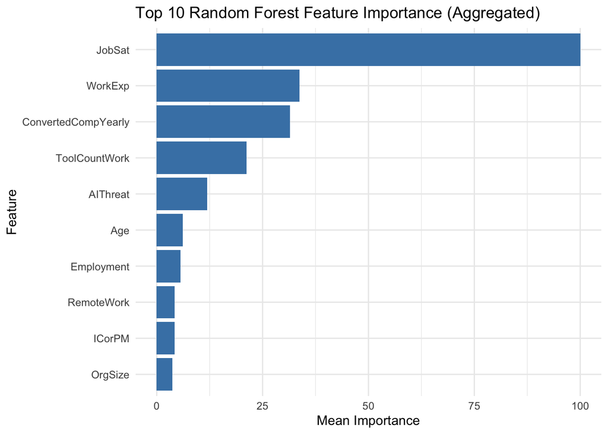

### Drop Job satisfaction

Since job satisfaction is highly predictive of career change and can dominate other factors, we remove it to better explore the influence of other variables on career mobility.

```r
# Drop JobSat
data$JobSat <- NULL
train$JobSat <- NULL
test$JobSat <- NULL

train_nb_logit$JobSat <- NULL
test_nb_logit$JobSat <- NULL
```

#### Naives Bayes

```r
set.seed(123)

ctrl <- trainControl(
  method = "repeatedcv",
  number = 5,
  repeats = 10,
  summaryFunction = twoClassSummary,
  classProbs = TRUE,
  savePredictions = "final"
)

nb_model <- train(
  NewRole ~ .,
  data = train_nb_logit,
  method = "naive_bayes",
  metric = "ROC",
  tuneLength = 10,
  trControl = ctrl
)

# Predictions and evaluation
nb_pred <- predict(nb_model, test_nb_logit)
confusionMatrix(nb_pred, test_nb_logit$NewRole, positive = "Change")

nb_probs <- predict(nb_model, test_nb_logit, type = "prob")[, "Change"]

roc_nb <- roc(response = test_nb_logit$NewRole, predictor = nb_probs, levels = rev(levels(test_nb_logit$NewRole)))
plot(roc_nb, print.auc = TRUE, main = "Naive Bayes ROC (without JobSat)")
```

**Output**

```
Confusion Matrix and Statistics

           Reference
Prediction  No_Change Change
  No_Change      2170   1757
  Change         2691   4039

               Accuracy : 0.5826
                 95% CI : (0.5732, 0.592)
    No Information Rate : 0.5439
    P-Value [Acc > NIR] : 4.321e-16

                  Kappa : 0.1455

 Mcnemar's Test P-Value : < 2.2e-16

            Sensitivity : 0.6969
            Specificity : 0.4464
         Pos Pred Value : 0.6001
         Neg Pred Value : 0.5526
             Prevalence : 0.5439
         Detection Rate : 0.3790
   Detection Prevalence : 0.6315
      Balanced Accuracy : 0.5716

       'Positive' Class : Change
```

**Plot**

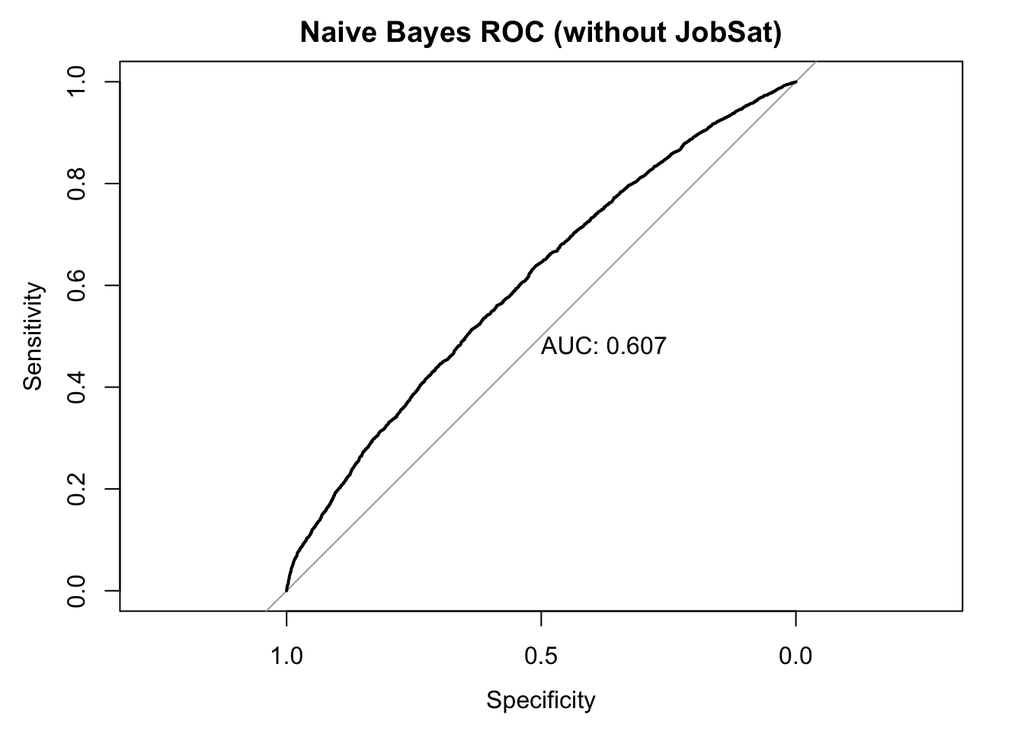

#### Logistic Regression (CV-Based Cutoff)

```r
# Train logistic regression
set.seed(123)
logit_model <- train(
  NewRole ~ .,
  data = train_nb_logit,
  method = "glm",
  family = binomial(),
  metric = "ROC",
  trControl = ctrl
)

# Extract CV predictions
cv_preds <- logit_model$pred

# ROC based on CV predictions
roc_cv <- roc(
  response  = cv_preds$obs,
  predictor = cv_preds$Change,  # predicted probability of 'Change'
  levels    = rev(levels(cv_preds$obs))
)

# Optimal threshold based on Youden's J (maximize overall accuracy)
cutoff <- coords(roc_cv, "best", ret = "threshold")$threshold
cutoff

# Predict probabilities on the test set
logit_probs_test <- predict(logit_model, newdata = test_nb_logit, type = "prob")[, "Change"]

# Apply optimal cutoff to classify
pred_test <- factor(
  ifelse(logit_probs_test > cutoff, "Change", "No_Change"),
  levels = levels(test_nb_logit$NewRole)
)

# Confusion matrix using CV-based cutoff
cm_test <- confusionMatrix(pred_test, test_nb_logit$NewRole, positive = "Change")
cm_test

# Plot ROC with threshold
plot(roc_cv, print.auc = TRUE, print.thres = "best",
     main = "Logistic Regression ROC (CV-based cutoff, without JobSat)")
```

**Output**

```
[1] 0.5264677
Confusion Matrix and Statistics

           Reference
Prediction  No_Change Change
  No_Change      2706   2139
  Change         2155   3657

               Accuracy : 0.5971
                 95% CI : (0.5877, 0.6064)
    No Information Rate : 0.5439
    P-Value [Acc > NIR] : <2e-16

                  Kappa : 0.1877

 Mcnemar's Test P-Value : 0.8189

            Sensitivity : 0.6310
            Specificity : 0.5567
         Pos Pred Value : 0.6292
         Neg Pred Value : 0.5585
             Prevalence : 0.5439
         Detection Rate : 0.3432
   Detection Prevalence : 0.5454
      Balanced Accuracy : 0.5938

       'Positive' Class : Change
```

**Plot**

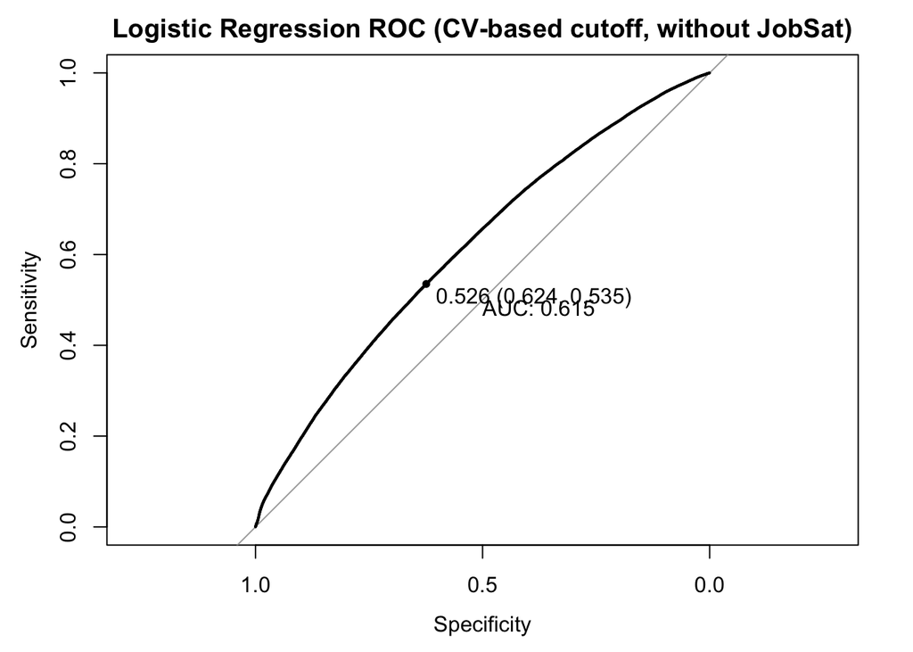

#### Random Forest

```r
set.seed(123)

rf_ctrl <- trainControl(
  method = "cv",
  number = 3,
  classProbs = TRUE,
  summaryFunction = twoClassSummary
)

rf_model <- train(
  NewRole ~ .,
  data = train,
  method = "ranger",
  metric = "ROC",
  tuneLength = 5,
  trControl = rf_ctrl,
  importance = "impurity",
  verbose = FALSE
)

rf_probs <- predict(rf_model, test, type = "prob")[, "Change"]

# ROC and optimal cutoff
roc_rf <- roc(response = test$NewRole, predictor = rf_probs, levels = rev(levels(test$NewRole)))
rf_cutoff <- coords(roc_rf, "best", ret = "threshold")$threshold

rf_pred_opt <- factor(ifelse(rf_probs > rf_cutoff, "Change", "No_Change"),
                      levels = levels(test$NewRole))

confusionMatrix(rf_pred_opt, test$NewRole, positive = "Change")

plot(roc_rf, print.auc = TRUE, print.thres = TRUE,
     main = paste("Random Forest ROC (cutoff =", round(rf_cutoff, 2), ", without JobSat)"))

# Variable importance
rf_varimp <- varImp(rf_model, scale = TRUE)$importance
rf_varimp <- data.frame(Variable = rownames(rf_varimp), Overall = rf_varimp$Overall, stringsAsFactors = FALSE)

map_to_orig <- function(var_name, predictors) {
  matches <- predictors[sapply(predictors, function(p) startsWith(as.character(var_name), as.character(p)))]
  if(length(matches) > 0) return(matches[which.max(nchar(matches))]) else return(var_name)
}

predictors <- names(train)[names(train) != "NewRole"]
rf_varimp$OrigVar <- sapply(rf_varimp$Variable, map_to_orig, predictors = predictors)

agg_varimp <- rf_varimp %>%
  group_by(OrigVar) %>%
  summarise(Importance = mean(Overall, na.rm = TRUE)) %>%
  arrange(desc(Importance))

top_varimp <- agg_varimp[1:10, ]

ggplot(top_varimp, aes(x = reorder(OrigVar, Importance), y = Importance)) +
  geom_col(fill = "steelblue") +
  coord_flip() +
  labs(title = "Top 10 Random Forest Features (without JobSat)",
       x = "Feature", y = "Mean Importance") +
  theme_minimal()
```

**Output**

```
Confusion Matrix and Statistics

           Reference
Prediction  No_Change Change
  No_Change      2591   2029
  Change         2270   3767

               Accuracy : 0.5966
                 95% CI : (0.5872, 0.6059)
    No Information Rate : 0.5439
    P-Value [Acc > NIR] : < 2.2e-16

                  Kappa : 0.1837

 Mcnemar's Test P-Value : 0.0002518

            Sensitivity : 0.6499
            Specificity : 0.5330
         Pos Pred Value : 0.6240
         Neg Pred Value : 0.5608
             Prevalence : 0.5439
         Detection Rate : 0.3535
   Detection Prevalence : 0.5665
      Balanced Accuracy : 0.5915

       'Positive' Class : Change
```

**Plot**

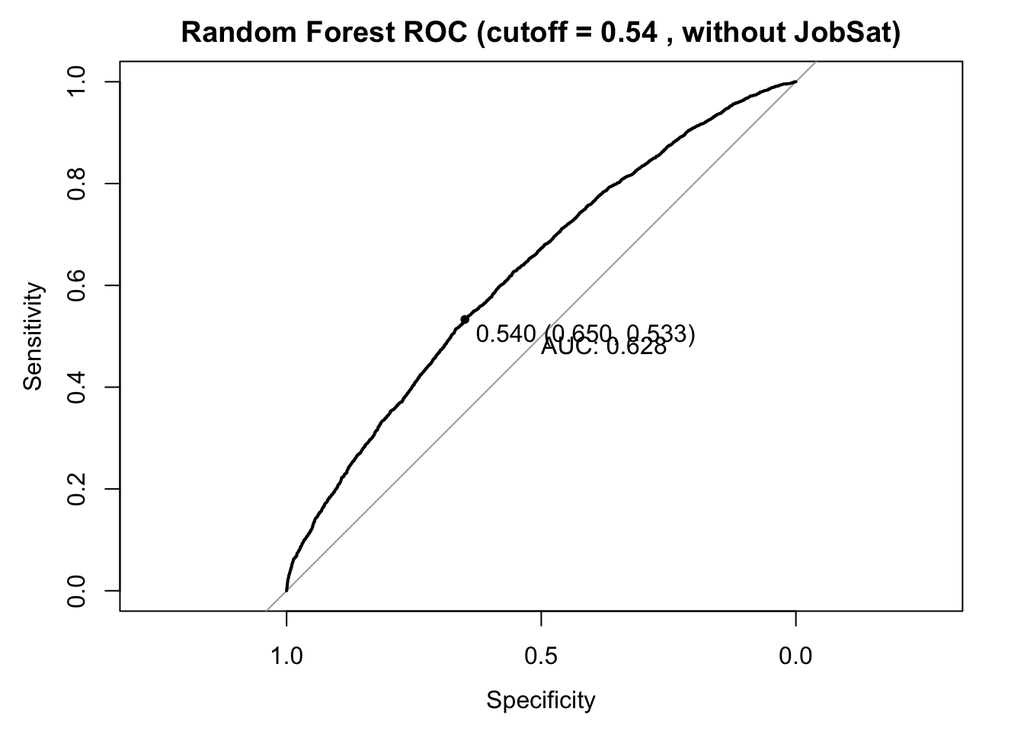

**Plot**

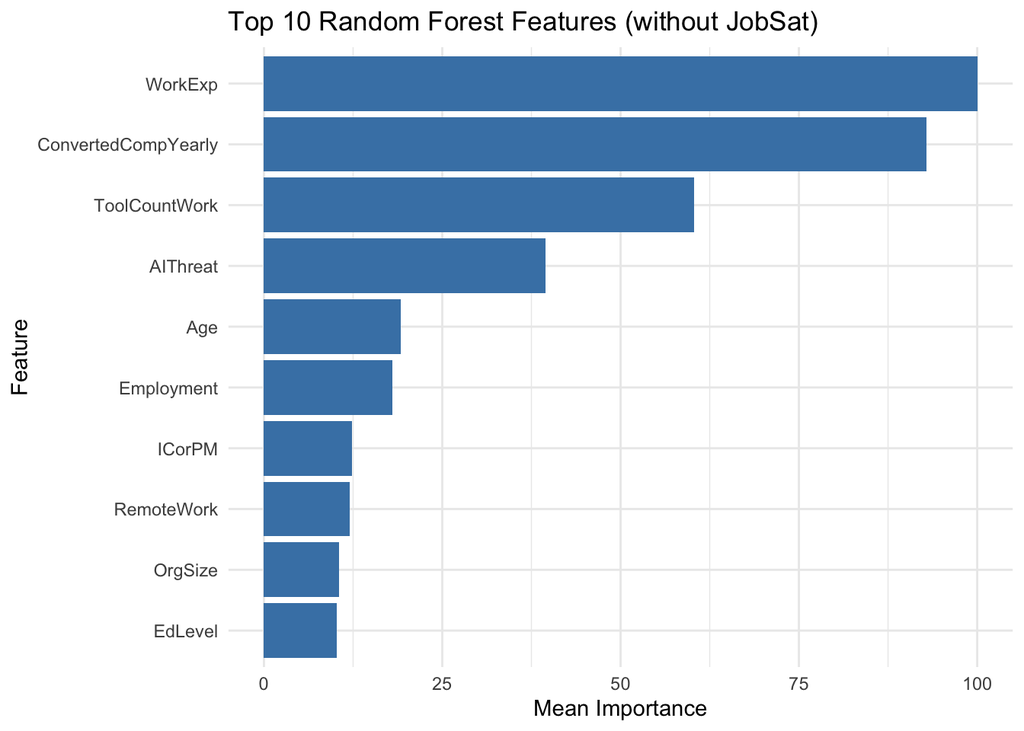

Work experience, compensation, the number of tools used and AI threat perception are top predictors.

## 7. Evaluation

### Model Performance (Including Job Satisfaction)

All three models perform pretty similarly, but with some trade-offs. Naive Bayes predicts the most developers who will switch jobs (highest sensitivity) but also mislabels more who stay. Logistic Regression is more balanced between catching changers and staying developers, and it’s easy to interpret. Random Forest has the best overall discrimination (highest AUC) but misses more changers than the other two.

Since predicting developers who switch is our main goal, Naive Bayes and Logistic Regression seem like the better choices. Naive Bayes is fast and does the best job at predicting who might switch, while Logistic Regression is more balanced and also lets us see which factors increase or decrease the odds of switching.

### Models Excluding Job Satisfaction

When we exclude job satisfaction, all models drop slightly in performance, showing that it was a strong predictor. Even without it, Naive Bayes and Logistic Regression still do a decent job. Naive Bayes keeps the highest sensitivity, so it’s still best for predicting developers likely to switch, while Logistic Regression remains more balanced and interpretable, letting us see which other factors influence switching. Random Forest performs reasonably well but doesn’t offer the same interpretability or sensitivity advantage.

### Overall Results

- Demographics: Younger developers (ages 25–44) are more likely to switch jobs, while older developers (55+) are less likely. Education level doesn’t appear to have an impact, but more work experience noticeably reduces the odds of switching.
- Job factors: Job satisfaction lowers the likelihood of switching. Certain roles, such as data or business analysts, full-stack developers, desktop or enterprise application developers, and students, tend to switch less, while freelancers or solo workers are more likely to change jobs. Organization size doesn’t seem to matter, and developers in the software development industry are slightly less likely to leave, while other industries show no clear effect. Using a greater number of distinct tools at work, reflecting higher job complexity, significantly increases the likelihood of switching.
- Compensation: Higher log-transformed compensation is associated with a lower probability of switching.
- Attitudinal factors: Job satisfaction clearly reduces switching, whereas perceiving AI as a threat significantly increases the likelihood of leaving.

No single model dominates across all metrics, but the results show that developer career change intentions can still be predicted reasonably well even without explicit job satisfaction data. This has practical implications: when satisfaction is unobserved or uncollected, organizations can rely on observable characteristics to identify employees at higher risk of turnover and implement targeted retention strategies.

Overall, this project demonstrates that career mobility among developers is shaped by a combination of experience, demographics, and work context, and that machine learning models, particularly Logistic Regression and Random Forest, can provide meaningful insights into these dynamics.

## 8.Limitations

- The analysis relies on survey responses, which may be subject to reporting bias and measurement error. Important factors influencing career change decisions may be missing or imperfectly measured.
- The models capture associations and predictive patterns rather than causal relationships. Results should be interpreted as correlational, not evidence that any factor directly causes career changes.
- The study focuses on internal and observable characteristics (e.g., demographics, job attributes, perceptions). External influences, such as better job offers, labor market conditions, company layoffs, visa constraints, or personal life events, are not captured but may strongly affect career mobility.

## 9. Conclusions & Recommendations

This project shows that developer career change intentions can be reasonably predicted using a combination of demographic, experiential, and work-context variables. Job satisfaction emerges as the strongest predictor, but even when it is excluded, models still perform moderately well, suggesting that career mobility is influenced by multiple interacting factors.

Recommendations:

- Organizations should monitor not only job satisfaction but also factors such as experience level, role type, workload, and perceptions of technological disruption (e.g., AI threat).
- When satisfaction data is unavailable, predictive models using observable characteristics can still help flag employees at higher risk of leaving.
- Future research could include external labor market data, longitudinal surveys, or causal methods to better understand why developers change careers and how interventions may reduce unwanted turnover.

Overall, these findings highlight that data-driven approaches can support proactive talent management, enabling more targeted retention strategies and informed decision-making within technical teams.